### VA Mental Health Clinic Research

###### Data can be found at https://github.com/amylovesdogs/SMU-MSDS-Homework/tree/master/homework/Unit10HW

```r
library(dplyr)
```

```r
library(knitr)
library(kableExtra)
library(ggplot2)
library(RColorBrewer)
library(data.table)
# Load the National Mental Health Services Survey (N-MHSS)
load("/Users/amypaschal/Documents/SMU/Term 1/Doing Data Science/Unit 10 /N-MHSS-2015-DS0001-bndl-data-r/N-MHSS-2015-DS0001-data/N-MHSS-2015-DS0001-data-r.rda")

# do a bit of data cleaning including removing white space and doing data conversions
# white space must be removed from the data in the LST column, otherwise matching state names
# will not be found equal in any comparisons and merging based on state abbreviations
# will fail
mh2015_puf$LST <- trimws(as.character(mh2015_puf$LST))
mh2015_puf$FACILITYTYPE <- as.numeric(mh2015_puf$FACILITYTYPE)

# pull all states and territories listed in the survey
states <- sort(unique(mh2015_puf$LST))

#  now get only mainland states and DC
outlying <- c('AK', 'AS', 'GU', 'HI', 'PR', 'VI')
mainland <- setdiff(states, outlying)
```

#### States Surveyed

###### AK, AL, AR, AS, AZ, CA, CO, CT, DC, DE, FL, GA, GU, HI, IA, ID, IL, IN, KS, KY, LA, MA, MD, ME, MI, MN, MO, MS, MT, NC, ND, NE, NH, NJ, NM, NV, NY, OH, OK, OR, PA, PR, RI, SC, SD, TN, TX, UT, VA, VI, VT, WA, WI, WV, WY

#### Number of VA Mental Health Facilities by State

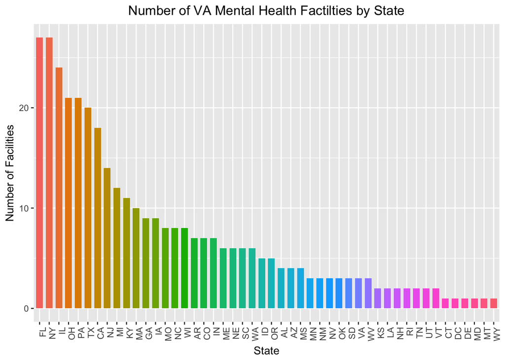

```r
# get rows for all facilities on the mainland
mh2015_mainland <- mh2015_puf[mh2015_puf$LST %in% mainland,]

# get rows for the VA hospitals, and only pull the interesting columns
mh2015_mainland_va <- mh2015_mainland[mh2015_mainland$FACILITYTYPE == 6, c("CASEID","LST","FACILITYTYPE")]

# set some more user-friendly column titles
names(mh2015_mainland_va) <- c("ID","State","Type")

# create a data frame with the number of facilities in each state and display
facility_count <- aggregate(c(count = ID) ~ State, data = mh2015_mainland_va, FUN = function(x){NROW(x)})
names(facility_count) <- c('State','Count')

# sort by Count descending in a way that makes ggplot happy
facility_count$State <- factor(facility_count$State, levels = facility_count$State[order(-facility_count$Count)])

# plot
ggplot(facility_count, aes(x=State, y=Count, fill=State)) +
geom_bar(stat="identity", width=.7) + theme(axis.text.x = element_text(angle = 90, hjust = 1), plot.title = element_text(hjust = 0.5), legend.position = "none") + labs(title="Number of VA Mental Health Factilties by State", x ="State", y = "Number of Facilities")
```

#### Number of VA Mental Health Facilities Per 1000 Square Miles by State

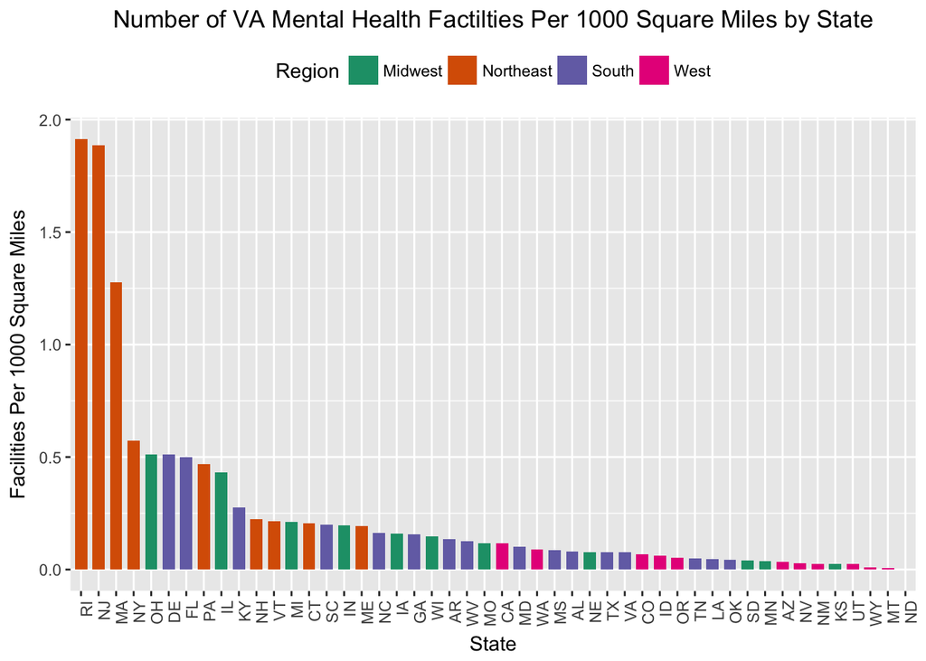

```r
# read in the state size data and do data conversions
state_size <- read.csv("statesize.csv", header = TRUE, colClasses = c('character', 'numeric', 'character', 'character'))

# filter for mainland facilities, pulling only the columns of interest
columns <- c("Abbrev","StateName","SqMiles","Region")
states_mainland <- state_size[state_size$Abbrev %in% mainland, columns]

# rename columns. One way to do the merge is to have the state abbreviaion column name in the state
# information dataframe match that of the same column in the facilities information
names(states_mainland) <- c("State","StateName", "SqMiles","Region")

facilities <- merge(facility_count, states_mainland, all = TRUE)

# since the merge included all rows, we have rows for DC, which was not in the state size file
# and ND which has no facilities.
# clean up that data, including adding the square milage of DC
facilities$Count[is.na(facilities$Count)] <- 0
facilities$StateName[facilities$State == "DC"] <- "District of Columbia"
facilities$Region[facilities$State == "DC"] <- "South"
facilities$SqMiles[facilities$State == "DC"] <- 68.34

# add a facilities per 1000 square miles variable
facilities$PerThousandSqMiles <- facilities$Count / (facilities$SqMiles / 1000)

# As it turns out DC thows the scale off, so remove DC to keep the scale reasonable
facilities_noDC <- facilities[(facilities$State != "DC"),]

# sort by PerThousandSqMiles descending in a way that makes ggplot happy
facilities_noDC$State <- factor(facilities_noDC$State, levels = facilities_noDC$State[order(-facilities_noDC$PerThousandSqMiles)])

# plot
ggplot(facilities_noDC, aes(x=State, y=PerThousandSqMiles, fill=Region)) +
geom_bar(stat="identity", width=.7) + theme(axis.text.x = element_text(angle = 90, hjust = 1), plot.title = element_text(hjust = 0.5), legend.position = "top") + labs(title="Number of VA Mental Health Factilties Per 1000 Square Miles by State", x ="State", y = "Facilities Per 1000 Square Miles") + scale_fill_brewer(palette="Dark2")
```

```r
# store the information for DC
dc <- facilities$PerThousandSqMiles[facilities$State == "DC"]
options(digits = 1)
```

###### Note: This graph does not include DC due to scaling issues. DC has 14.6 facilities per 1000 square miles.

#### Patterns

###### The graph shows that the region with the highest number of VA medical centers per 1000 square miles is the Northest and that with the lowest is the West.

###### An exception here is ND with no facilities at all.

###### Given that the Northeast is the most densely populated region and the West, the least, I would suggest examining centers per unit of population as well.

#### Population

##### Full State Population (2017 US Census Bureau Data)

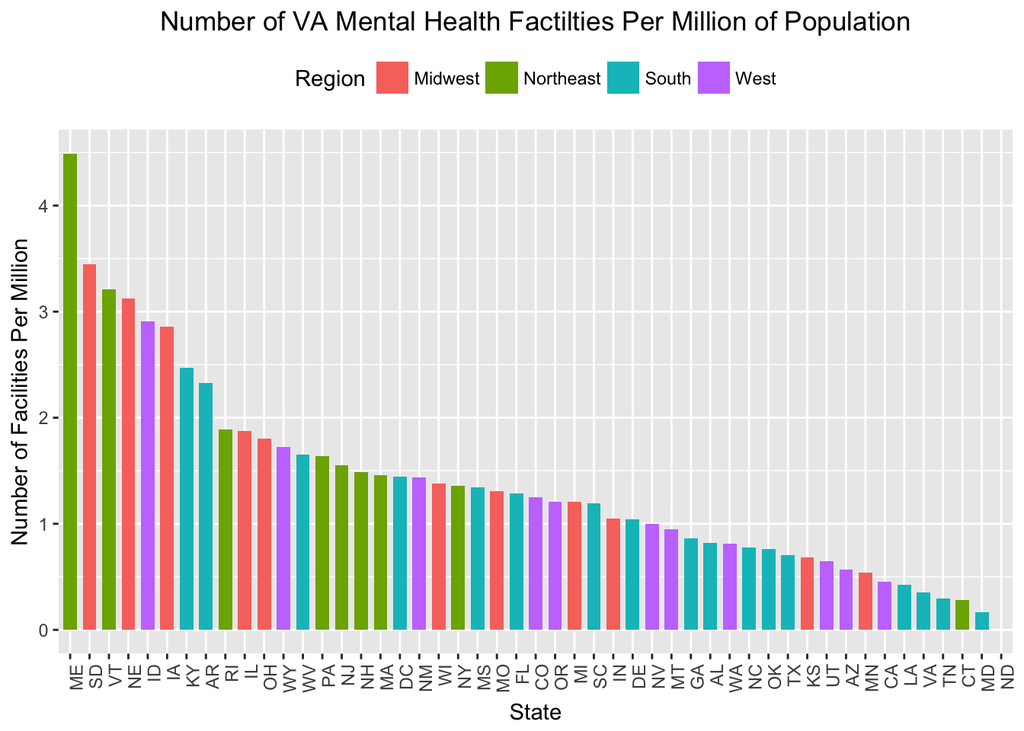

```r
# 2017 state population gathered from the U.S. census bureau
state_pop <- read.csv("census.csv", header = TRUE, colClasses = c('character', 'numeric'))

# merge population into facilities
facilities <- merge(facilities, state_pop)
facilities$PerMillionPop <- facilities$Count / (facilities$Population / 1000000)

# sort by PerMillionPop descending in a way that makes ggplot happy
facilities$State <- factor(facilities$State, levels = facilities$State[order(-facilities$PerMillionPop)])

# plot
ggplot(facilities, aes(x=State, y=PerMillionPop, fill=Region)) +
geom_bar(stat="identity", width=.7) + theme(axis.text.x = element_text(angle = 90, hjust = 1), plot.title = element_text(hjust = 0.5), legend.position = "top") + labs(title="Number of VA Mental Health Factilties Per Million of Population", x ="State", y = "Number of Facilities Per Million")
```

#### Population of Veterans (2016 US Census Bureau Data)

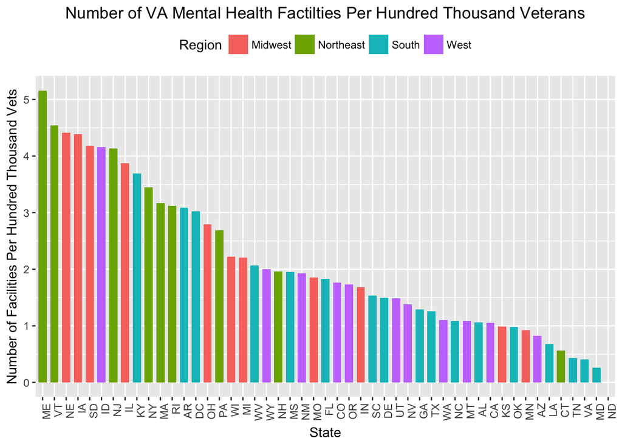

```r
# 2016 veteran population by state from the US census bureau
state_vets <- read.csv("veterans.csv", header = TRUE, colClasses = c('character', 'numeric'))

# merge population into facilities
facilities <- merge(facilities, state_vets)
facilities$PerHundredThousandVets <- facilities$Count / (facilities$VeteranPop / 100000)

# sort by PerMillionPop descending in a way that makes ggplot happy
facilities$State <- factor(facilities$State, levels = facilities$State[order(-facilities$PerHundredThousandVets)])

# plot
ggplot(facilities, aes(x=State, y=PerHundredThousandVets, fill=Region)) +
geom_bar(stat="identity", width=.7) + theme(axis.text.x = element_text(angle = 90, hjust = 1), plot.title = element_text(hjust = 0.5), legend.position = "top") + labs(title="Number of VA Mental Health Factilties Per Hundred Thousand Veterans", x ="State", y = "Number of Facilities Per Hundred Thousand Vets")
```

#### Patterns

###### According to this graph, the Northeast still has a strong showing but not nearly to the degree the square mileage analysis would indicate.

###### This graph shows the clearest need overall is in the south. ND still has zero facilities but the Dakotas taken together fall about mid-range.

###### Both population and square mileage should be taken into account because travel can be prohibitive as well as long lines.